# Goodreads Data as a Measure of Issue Salience

The Case of Race & Politics

Kallan Larsen & Lingxi Li

2019-12-11

## Motivation

Issue salience is an important aspect of studies of sociopolitical life and specifically voter behavior. “Issue voting” is a foundational theory in political science (Carmines & Stimson 1980). A political figure’s involvement in salient issues has a substantial impact on her approval ratings (Edwards, Mitchell, & Welch 1995).

Not every measurement of issue salience is appropriate for every research question. Mayhew (1991) outlines this distinction temporally; measures of retrospective and contemporaneous issue salience may differ from one another. Additionally, it is important to determine whether one wants to study political elites or popular issue salience, as the sources of issue salience for each may be quite different. Whether a case concerning an issue is included in constitutional law books (Danelski 1989), for example, may be an important factor in determining the salience of that issue for those in the field of law, but not for a layperson who has never opened a constitutional law book.

The issues that are salient to political elites (e.g., legislators, justices, and other politicians) may have a notable effect on policies that are put into place. Popular salience, however, can both influence political elites and be influenced by new policies enacted by political elites. In Epstein and Segal’s (2000) study of issue salience to US Supreme Court justices, they use media coverage to measure issue salience. This may be a rare source that could measure issue salience for all consumers of media, regardless of whether they are politicians or not. Indeed, many researchers continue to analyze media coverage of Donald Trump and Hillary Clinton leading up to the 2016 US Presidential Election. However, using media coverage as a measures of issue salience requires heroic assumptions regarding uniform media exposure – people do not read, watch, or listen to the same news sources, let alone the same stories, for the same amount of time each day, so stimuli vary immensely.

Many political polls ask voters to report the most important issue to them, but Bartle & Laycock (2012) find limited evidence that these measures actually influence voting behavior. They posit that respondents are reporting what they observe as being important to other voters, not necessarily what is most important for them personally. Found data such as Twitter data can be used to get a real-time picture of popular sentiment regarding candidates and political issues, but tweets can be sent out in a matter of seconds and therefore may not represent crystallized issue salience or issue salience over long periods of time.

From an observational standpoint, race seems to be a topic that has become more and more popular in media – whether films, literature, or public discourse. Race salience has important implications for public policy. As an example, Grissom, Nicholson-Crotty, and Nicholson-Crotty (2009) demonstrate that the benefits afforded to Black students by Black teachers differs by region according to the salience of race in a particular region.

As a comparison, we observe the issue salience of politics in the context of American presidents since 1960 (11 presidents, with elections occur every four years).

## Research Questions

How salient are the issues of race and politics to the public, and how has the salience of these topics changed over time? Does the popularity of books about race correspond with important events pertaining to race in the United States, and/or does the popularity of books about politics correspond with important political events in the United States? To what extent does the popularity of books about race and politics overlap?

## Data

### Source

In this paper, we use a measure of issue salience that, to our knowledge, has never been used for this purpose: Goodreads data. Goodreads is a social networking website that allows users to flag books they have read or want to read and post reviews and ratings of the books. As of July 2019, Goodreads had more than 90 million users, more than 10 million books added to its online catalogs, 50 million unique visitors per month, and more than 50 million user reviews. Users can also “tag” books, a feature that is used to mark books as being part of a certain genre or being about certain topics, among others. Goodreads compiles lists of books that share a tag, which makes comparisons of books that share characteristics fairly convenient. It is these lists that we use to measure issue salience.

Publishers often share the most popular genres of books each year, but this is usually based on book sales, not reader opinions, and genres are not crystallized enough to be informative about issue salience. For example, there could be both novels and non-fiction books making powerful statements about race in a given year, but publisher data does not reflect that. Goodreads allows books from all publishers to be gathered in one place, and topics are available on a more granular level, although we have to rely on users to tag books as being about the topics of interest. The Pew Research Center reports that more Americans, especially young Americans, are turning to books to research specific topics (Perrin 2016), which leads us to believe that data about the books people are choosing to read is a promising source of information pertaining to issue salience.

### Gathering

##### List1: Books about race

```r
#create loop to get average rating, number of rating, published year
PAGE<-25
f_pubyr<-data.frame()
for (i in 1:PAGE) {
  url <- paste0("https://www.goodreads.com/shelf/show/race?page=",i)
  page<-jump_to(pgsession, url)
  nds <- html_nodes(page, xpath = '//*[contains(concat( " ", @class, " " ), concat( " ", "greyText", " " )) and contains(concat( " ", @class, " " ), concat( " ", "smallText", " " ))]')
  pub_yr <- html_text(nds)
  pub_yr<-as.data.frame(pub_yr)
  f_pubyr<-rbind(f_pubyr,pub_yr)
}
#create a loop to get book names
PAGE<-25
f_rana<-data.frame()
for (i in 1:PAGE) {
  url <- paste0("https://www.goodreads.com/shelf/show/race?page=",i)
  page <- jump_to(pgsession, url)
  nds <- html_nodes(page, xpath = '//*[contains(concat( " ", @class, " " ), concat( " ", "bookTitle", " " ))]')
  race_name <- html_text(nds)
  race_name <- as.data.frame(race_name)
  f_rana <- rbind(f_rana,race_name)
}
```

##### List3: Top 200 Books for Each Year

```r
#get the names of top 200 books from 1960 to 2019
YEAR<-2019  #1960-2019
f_top<-data.frame()

for (i in 1960:YEAR) {
  url <- paste0("https://www.goodreads.com/book/popular_by_date/",i)
  page <- jump_to(pgsession, url)
  nds <- html_nodes(page, xpath = '//*[contains(concat( " ", @class, " " ), concat( " ", "bookTitle", " " ))]//span')
  top_name <- html_text(nds)
  top_name <- as.data.frame(top_name)
  f_top <- rbind(f_top,top_name)
}
#clean the data
f_top$top_name<-trimws(f_top$top_name,which="both")
f_top$top_name<-gsub("\\s*\\([^\\)]+\\)","",f_top$top_name)
```

## Results

We expected the number of books about politics to be higher because it is a relatively broader topic and often overlaps with race. We also expected that the number of books in general would be higher in more recent years due to an influx in both self-publishing books and in use of Goodreads.

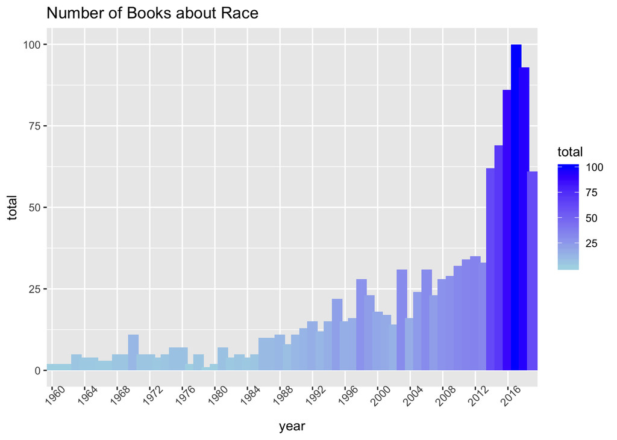

```r
#bar chart: Number of books about race per year
#filter out NA and blank
f_race %>%
  filter(year!="" & year>=1960) %>%
  group_by(year) %>%
  summarise(total=n()) %>%
  ggplot(aes(year,total,fill=total))+
  geom_col(width=1.3)+
  scale_fill_continuous(low="light blue", high="blue")+
  scale_x_discrete(breaks = seq(1960, 2020, by = 4)) +
  ggtitle("Number of Books about Race") +
  theme(axis.text.x = element_text(angle = 45))
```

We see that there has been a huge spike in the number of books published about race, starting around 2014.

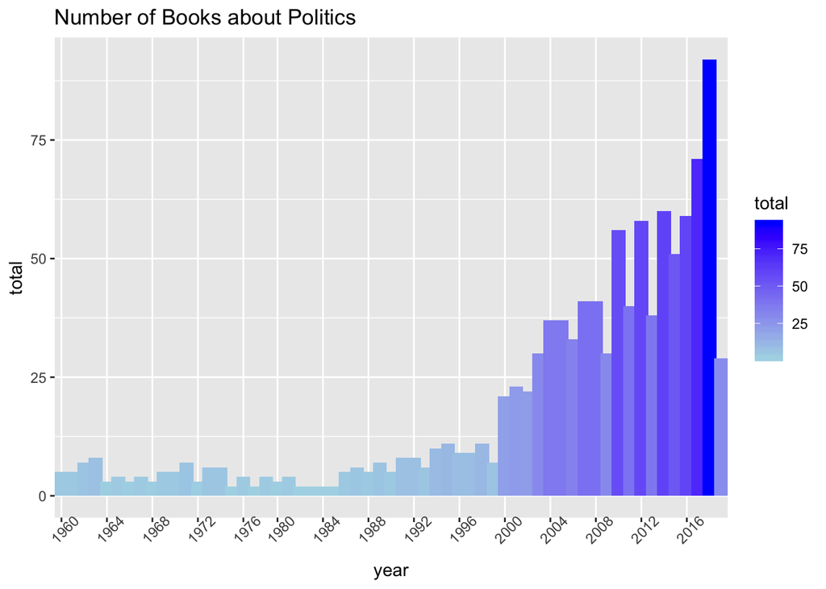

```r
#bar chart: Number of books about politics per year
#filter out NA and blank
f_politics %>%
  filter(year!="" & year>=1960) %>%
  group_by(year) %>%
  summarise(total=n()) %>%
  ggplot(aes(year,total,fill=total))+
  geom_col(width=1.2)+
  scale_fill_continuous(low="light blue", high="blue")+
  scale_x_discrete(breaks = seq(1960, 2020, by = 4)) +
  ggtitle("Number of Books about Politics") +
  theme(axis.text.x = element_text(angle = 45))
```

There has also been a large increase in the number of political books published per year, but this increase starts earlier and is more gradual than the trend of books about race. Additionally, the number of books is not as high as it is for race. This could potentially be explained by there being more novels about race than politics (so the combination of nonfiction and fiction leads to a higher overall number), but we do not perform that analysis here.

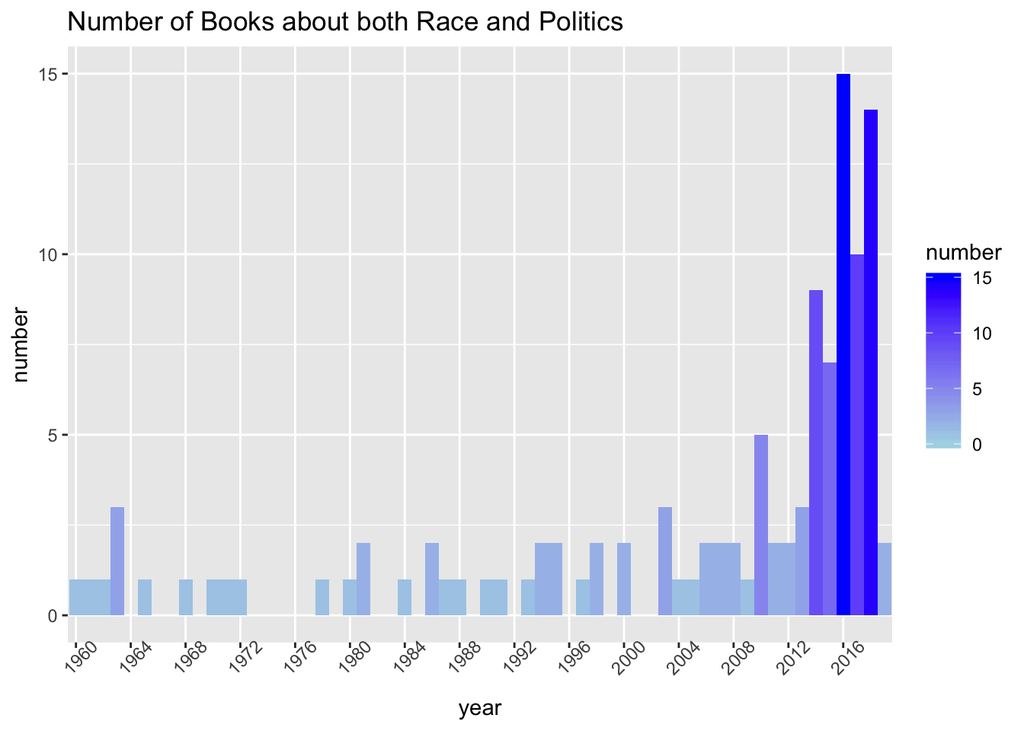

```r
#intersection: politics and race
pora_inter <- data.frame()
for (i in 1960:2019) {
  year_group_ra <- which(f_race$year==i)
  year_group_po <- which(f_politics$year==i)
  intersection <- intersect(f_race$race_name[year_group_ra],f_politics$politics_name[year_group_po])
  intersection <- as.data.frame(length(intersection))
  pora_inter <- rbind(pora_inter,intersection)
}
names(pora_inter)<-"number"
#append column of year
pora_inter$year <- c(1960:2019)
pora_inter$year <- as.factor(pora_inter$year)
#plot of the intersection number
ggplot(pora_inter,aes(x=year,y=number,fill=number))+
  geom_col(width=1)+
  ggtitle("Number of Books about both Race and Politics") +
  scale_fill_continuous(low="light blue", high="blue")+
  scale_x_discrete(breaks = seq(1960, 2020, by = 4)) +
  theme(axis.text.x = element_text(angle = 45))
```

The intersection of race and politics, at least as tagged by Goodreads users, is much lower than expected. The highest intersection is 15 books and occurs in 2016.

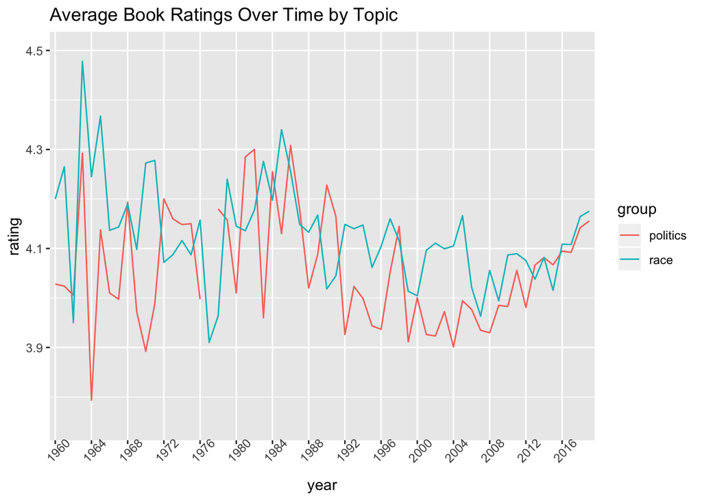

```r
#combine ratings of books on both topics
racerate<-f_race %>%
  filter(year!="" & year>=1960) %>%
  group_by(year) %>%
  summarise(race=mean(as.numeric(rating)))
polirate<-f_politics %>%
  filter(year!="" & year>=1960) %>%
  group_by(year) %>%
  summarise(politics=mean(as.numeric(rating)))
f_rating<-full_join(racerate, polirate, by="year")
f_rating %>%
  gather(key="group", value="rating", 2:3) %>%
  ggplot(aes(x=year,y=rating, group=group, color=group))+
  geom_line()+
  ylim(3.75,4.5)+
  ggtitle("Average Book Ratings Over Time by Topic") +
  scale_x_discrete(breaks = seq(1960, 2020, by = 4)) +
  theme(axis.text.x = element_text(angle = 45))
```

Analysis of average ratings by year is not very informative, as ratings of books about race seem to be relatively similar throughout the time period of interest. Almost all average ratings are between 3.9 and 4.3. Note that there is a gap in the politics line in 1977. No books written in 1977 were tagged as being about politics. If they were tagged, they were not rated at all.

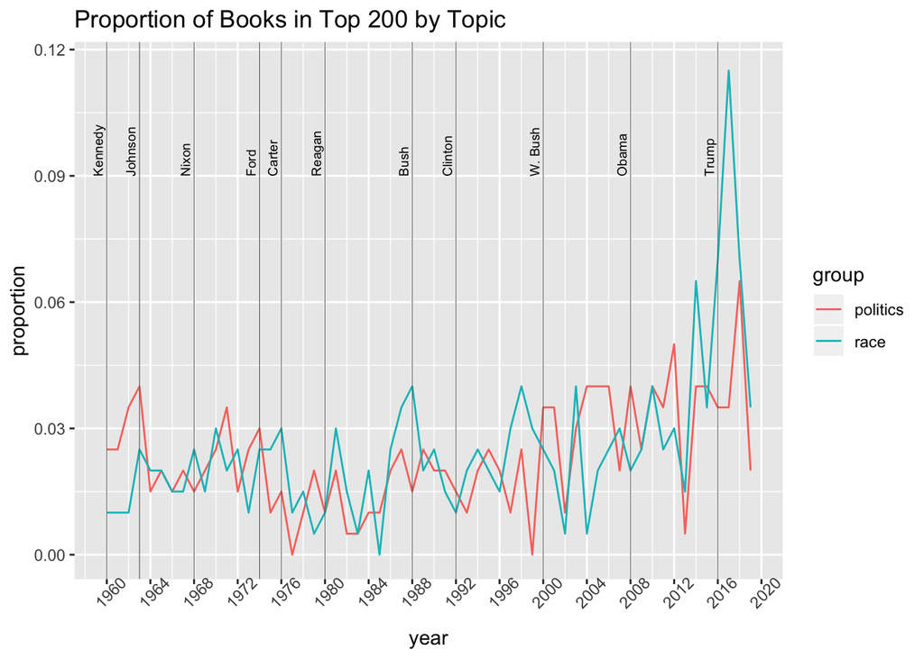

```r
popular_inter1$group<-"race"
popular_inter$group<-"politics"
combine<-rbind(popular_inter1, popular_inter)
combine$year<-as.numeric(as.character(combine$year))
#election
ggplot()+
  geom_line(data=combine,aes(x=year,y=proportion,group=group,color=group))+
  geom_vline(data=elections, aes(xintercept=year), color="dimgray",size=0.2)+
  geom_text(data=elections, aes(x=year, y=0.09, label=president),size=2.5, angle=90, vjust=-0.4, hjust=0)+
  ggtitle("Proportion of Books in Top 200 by Topic")+
  scale_x_continuous(breaks = seq(1960, 2020, by = 4))+
  ylim(0,0.116)+
  theme(axis.text.x = element_text(angle = 45))
```

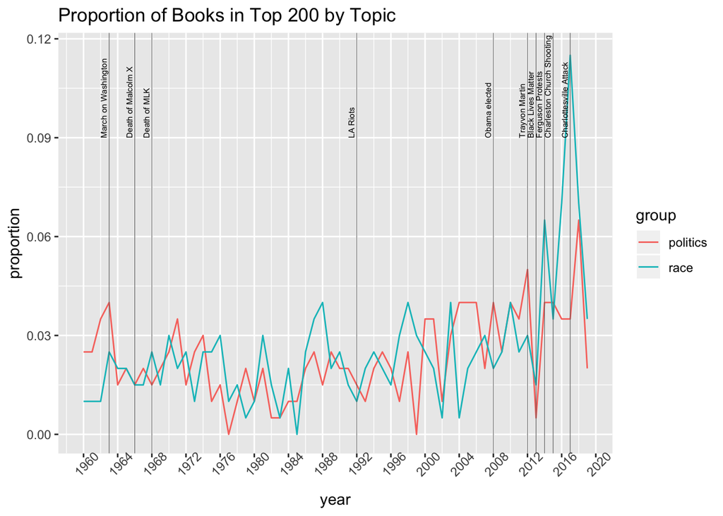

```r
#race events
ggplot()+
  geom_line(data=combine,aes(x=year,y=proportion,group=group,color=group))+
  geom_vline(data=raceevents, aes(xintercept=eventyear), color="dimgrey",size=0.2)+
  geom_text(data=raceevents, aes(x=eventyear, y=0.09, label=event),size=2, angle=90, vjust=-0.4, hjust=0)+
  ggtitle("Proportion of Books in Top 200 by Topic")+
  scale_x_continuous(breaks = seq(1960, 2020, by = 4))+
  ylim(0,0.116)+
  theme(axis.text.x = element_text(angle = 45))
```

## Discussion

This data shows that the issue salience of race and politics, as measured by the popularity of books on such topics, has increased in recent years. This effect is greater for race than for politics. This result is surprising in that one might expect a greater proportion of the top 200 books in a year to be about politics rather than race because it is a broader topic, but not surprising when put in the context of the Black Lives Matter movement (founded in 2013) and the events that have propelled it. While US elections are a regular occurence, the events that seem to be leading to increased race salience are not and may, therefore, have a more novel effect.

Our use of Goodreads data is limited – we cannot refine ratings to include only readers from a specific location (country), we cannot tell whether someone who rated a book actually read the book, and we cannot limit our data to books published in the United States. Accessing demographic data about Goodreads users is also difficult, and of course, there are readers who don’t use Goodreads and citizens who do not read at all. However, we argue that the nature of Goodreads data is such that falsifying whether or not one has read a book is not incentivized; Goodreads ratings do not seem to have a large enough of an impact on the book industry for falsifying reviews to be as common as it might be on, for example, business review sites such as Yelp. As Goodreads becomes more mainstream, this may change.

We cannot observe when books were read in this data, which poses a bigger problem for older books than newer books. For example, if someone read and rated To Kill a Mockingbird in 2015, any rating shift in To Kill a Mockingbird would affect the results for 1960 (the year the book was published), not 2015. Our current measures reflect the most popular books from each year as determined by Goodreads readers, not the most popular books of that year as determined by that year’s readers. Future research could explore records of bestselling books by year and match them with Goodreads data to obtain topical tags.

Additionally, the tagging feature on Goodreads is subject to error. It is plausible that a book about race and/or politics exists but has never been flagged by a user as being about that topic. We acknowledge this limitation while trusting, however naively, that the most popular books (and thus the most likely to have an impact on issue salience) will be flagged by devoted Goodreads users. Our selection of important racial and political events is yet another limitation of this analysis; one could reasonably do the same analysis using an entirely different set of events. Making any sort of causal inference based on historical events is a lofty task, however, and we are confident that our selected dates were of some importance. Future research might explore the salience of other issues using Goodreads data or move on to sites such as Letterboxd, which is a site very similar to Goodreads used for tracking films rather than books.

This research is the first, to our knowledge, to use Goodreads data as a measure of issue salience. When studied in the context of historical events, there seems to be a relationship between the popularity of books on race and politics and the events that might spark that increased salience. Despite substantial potential for errors of representation, it is an exciting and innovative use of a unique source of found data.

## References

Bartle, J., & Laycock, S. (12/2012). Telling more than they can know? Does the most important issue really reveal what is most important to voters? Electoral Studies, 31(4), 679–688. Elsevier Ltd.

Carmines, E. G., & J. A. Stimson. (1/3/1980). The Two Faces of Issue Voting. The American Political Science Review, 74(1), 78–91. The American Political Science Association.

Danelski, D. J. 1989. “The Influence of the Chief Justice in the Decisional Process of the Supreme Court.” In American Court Systems, ed. Sheldon Goldman and Austin Sarat. New York: Longman.

Edwards, G. C., W. Mitchell, & R. Welch. (1995). Explaining Presidential Approval: The Significance of Issue Salience. American Journal of Political Science, 39(1), 108-134. University of Wisconsin Press.

Epstein, L., & J. A. Segal. (1/1/2000). Measuring Issue Salience. American Journal of Political Science, 44(1), 66–83. University of Wisconsin Press.

Grissom, J. A., J. Nicholson-Crotty, & S. Nicholson-Crotty. (1/9/2009). Race, Region, and Representative Bureaucracy. Public Administration Review, 69(5), 911–919. article, Oxford, UK: Wiley Subscription Services.

Mayhew, D. R. 1991. Divided We Govern. New Haven: Yale University Press.

Perrin, A. (2016). “Book Reading 2016.” Pew Research Center. https://www.pewresearch.org/internet/2016/09/01/book-reading-2016/

## Github Link

https://github.com/lingxi-l/727-Final-Project